# Credit card fraud detection

### Problem Statement

- The Credit Card Fraud Detection Problem includes modeling past credit card transactions with the knowledge of the ones that turned out to be fraud. This model is then used to identify whether a new transaction is fraudulent or not. Our aim here is to detect 100% of the fraudulent transactions while minimizing the incorrect fraud classifications.

### Data set

- The dataset is taken from https://github.com/221710304062/Credit-card-fraud-detection-Project ##### The given dataset contains following parameters:
- This dataset presents transactions that occurred in two days, where we have 492 frauds out of 284,079 transactions.
- The dataset is highly unbalanced, the positive class (frauds) account for 0.173% of all transactions.
- It contains only numeric input variables which are the result of a PCA transformation.
- Features V1, V2, … V28 are the principal components obtained with PCA, the only features which have not been transformed with PCA are 'Time' and 'Amount'.
- Feature 'Time' contains the seconds elapsed between each transaction and the first transaction in the dataset.
- The feature 'Amount' is the transaction Amount, this feature can be used for example-dependant cost-sensitive learning.
- Feature 'Class' is the response variable and it takes value 1 in case of fraud and 0 otherwise.

#### Importing required libraries

```python
#importing the required packages
import pandas as pd
import seaborn as sns
import numpy as np
import matplotlib.pyplot as plt
%matplotlib inline
```

#### Versions of packages

```python
#Checking the versions of the packages imported
import numpy
import matplotlib
print('numpy:',numpy.__version__)
print('pandas:',pd.__version__)
print('seaborn:',sns.__version__)
print('matplotlib:',matplotlib.__version__)
```

```
numpy: 1.18.1
pandas: 1.0.3
seaborn: 0.10.1
matplotlib: 3.2.1
```

#### Reading the dataset

```python
#reading the dataset using pandas
data = pd.read_csv("creditcard1.csv")
data.head()  #To display top 5 rows of the dataset.
```

|  | Time | V1 | V2 | V3 | V4 | V5 | V6 | V7 | V8 | V9 | ... | V21 | V22 | V23 | V24 | V25 | V26 | V27 | V28 | Amount | Class |
| --- | --- | --- | --- | --- | --- | --- | --- | --- | --- | --- | --- | --- | --- | --- | --- | --- | --- | --- | --- | --- | --- |
| 0 | 0.0 | -1.359807 | -0.072781 | 2.536347 | 1.378155 | -0.338321 | 0.462388 | 0.239599 | 0.098698 | 0.363787 | ... | -0.018307 | 0.277838 | -0.110474 | 0.066928 | 0.128539 | -0.189115 | 0.133558 | -0.021053 | 149.62 | 0 |
| 1 | 0.0 | 1.191857 | 0.266151 | 0.166480 | 0.448154 | 0.060018 | -0.082361 | -0.078803 | 0.085102 | -0.255425 | ... | -0.225775 | -0.638672 | 0.101288 | -0.339846 | 0.167170 | 0.125895 | -0.008983 | 0.014724 | 2.69 | 0 |
| 2 | 1.0 | -1.358354 | -1.340163 | 1.773209 | 0.379780 | -0.503198 | 1.800499 | 0.791461 | 0.247676 | -1.514654 | ... | 0.247998 | 0.771679 | 0.909412 | -0.689281 | -0.327642 | -0.139097 | -0.055353 | -0.059752 | 378.66 | 0 |
| 3 | 1.0 | -0.966272 | -0.185226 | 1.792993 | -0.863291 | -0.010309 | 1.247203 | 0.237609 | 0.377436 | -1.387024 | ... | -0.108300 | 0.005274 | -0.190321 | -1.175575 | 0.647376 | -0.221929 | 0.062723 | 0.061458 | 123.50 | 0 |
| 4 | 2.0 | -1.158233 | 0.877737 | 1.548718 | 0.403034 | -0.407193 | 0.095921 | 0.592941 | -0.270533 | 0.817739 | ... | -0.009431 | 0.798278 | -0.137458 | 0.141267 | -0.206010 | 0.502292 | 0.219422 | 0.215153 | 69.99 | 0 |

5 rows × 31 columns

#### To check number of rows and columns in the given dataset.

```python
#checking the total number of columns and rows in the given dataset.
data.shape
```

```
(284079, 31)
```

```python
#To display all the column names in the dataset
data.columns
```

```
Index(['Time', 'V1', 'V2', 'V3', 'V4', 'V5', 'V6', 'V7', 'V8', 'V9', 'V10',
       'V11', 'V12', 'V13', 'V14', 'V15', 'V16', 'V17', 'V18', 'V19', 'V20',
       'V21', 'V22', 'V23', 'V24', 'V25', 'V26', 'V27', 'V28', 'Amount',
       'Class'],
      dtype='object')
```

```python
#To display the information of the columns.
data.info()
```

```
<class 'pandas.core.frame.DataFrame'>
RangeIndex: 284079 entries, 0 to 284078
Data columns (total 31 columns):
Time      284079 non-null float64
V1        284079 non-null float64
V2        284079 non-null float64
V3        284079 non-null float64
V4        284079 non-null float64
V5        284079 non-null float64
V6        284079 non-null float64
V7        284079 non-null float64
V8        284079 non-null float64
V9        284079 non-null float64
V10       284079 non-null float64
V11       284079 non-null float64
V12       284079 non-null float64
V13       284079 non-null float64
V14       284079 non-null float64
V15       284079 non-null float64
V16       284079 non-null float64
V17       284079 non-null float64
V18       284079 non-null float64
V19       284079 non-null float64
V20       284079 non-null float64
V21       284079 non-null float64
V22       284079 non-null float64
V23       284079 non-null float64
V24       284079 non-null float64
V25       284079 non-null float64
V26       284079 non-null float64
V27       284079 non-null float64
V28       284079 non-null float64
Amount    284079 non-null float64
Class     284079 non-null int64
dtypes: float64(30), int64(1)
memory usage: 67.2 MB
```

```python
#To display the statistical information of the columns
data.describe().T
```

|  | count | mean | std | min | 25% | 50% | 75% | max |
| --- | --- | --- | --- | --- | --- | --- | --- | --- |
| Time | 284079.0 | 9.461489e+04 | 47385.817047 | 0.000000 | 54116.000000 | 84558.000000 | 139096.000000 | 172136.000000 |
| V1 | 284079.0 | 1.664778e-04 | 1.958508 | -56.407510 | -0.920166 | 0.018583 | 1.315363 | 2.454930 |
| V2 | 284079.0 | -1.035871e-03 | 1.651394 | -72.715728 | -0.598942 | 0.065034 | 0.803043 | 22.057729 |
| V3 | 284079.0 | 1.886829e-03 | 1.515581 | -48.325589 | -0.887673 | 0.181830 | 1.028302 | 9.382558 |
| V4 | 284079.0 | 3.243236e-04 | 1.415728 | -5.683171 | -0.848578 | -0.019310 | 0.744225 | 16.875344 |
| V5 | 284079.0 | -5.864321e-04 | 1.378626 | -113.743307 | -0.692343 | -0.055104 | 0.611071 | 34.801666 |
| V6 | 284079.0 | 2.464160e-04 | 1.331494 | -26.160506 | -0.767913 | -0.273709 | 0.398966 | 73.301626 |
| V7 | 284079.0 | -4.844189e-04 | 1.234843 | -43.557242 | -0.554172 | 0.039755 | 0.570017 | 120.589494 |
| V8 | 284079.0 | -3.234414e-04 | 1.194679 | -73.216718 | -0.208497 | 0.022384 | 0.327114 | 20.007208 |
| V9 | 284079.0 | -1.336285e-04 | 1.098633 | -13.434066 | -0.643442 | -0.051715 | 0.597270 | 15.594995 |
| V10 | 284079.0 | -5.556518e-05 | 1.088098 | -24.588262 | -0.535205 | -0.092777 | 0.454155 | 23.745136 |
| V11 | 284079.0 | 1.033724e-03 | 1.020768 | -4.797473 | -0.761462 | -0.031380 | 0.740437 | 12.018913 |
| V12 | 284079.0 | -5.616045e-04 | 0.999805 | -18.683715 | -0.406279 | 0.139628 | 0.618200 | 7.848392 |
| V13 | 284079.0 | 6.002220e-05 | 0.995510 | -5.791881 | -0.648567 | -0.013626 | 0.662532 | 7.126883 |
| V14 | 284079.0 | 3.602050e-04 | 0.958662 | -19.214325 | -0.425077 | 0.050806 | 0.493186 | 10.526766 |
| V15 | 284079.0 | 4.598833e-04 | 0.915541 | -4.498945 | -0.582347 | 0.048756 | 0.649746 | 8.877742 |
| V16 | 284079.0 | -4.323618e-05 | 0.876327 | -14.129855 | -0.468306 | 0.066318 | 0.523414 | 17.315112 |
| V17 | 284079.0 | 9.132299e-05 | 0.849565 | -25.162799 | -0.483593 | -0.065539 | 0.399722 | 9.253526 |
| V18 | 284079.0 | -3.831342e-04 | 0.838333 | -9.498746 | -0.498850 | -0.003997 | 0.500487 | 5.041069 |
| V19 | 284079.0 | 8.474311e-06 | 0.814041 | -7.213527 | -0.456434 | 0.003772 | 0.459145 | 5.591971 |
| V20 | 284079.0 | 2.406212e-07 | 0.771349 | -54.497720 | -0.211748 | -0.062421 | 0.133133 | 39.420904 |
| V21 | 284079.0 | -1.140360e-05 | 0.735091 | -34.830382 | -0.228332 | -0.029452 | 0.186196 | 27.202839 |
| V22 | 284079.0 | -1.834385e-04 | 0.725602 | -10.933144 | -0.542194 | 0.006675 | 0.528046 | 10.503090 |
| V23 | 284079.0 | -1.130614e-04 | 0.624914 | -44.807735 | -0.161900 | -0.011293 | 0.147478 | 22.528412 |
| V24 | 284079.0 | 1.417645e-05 | 0.605713 | -2.836627 | -0.354549 | 0.041082 | 0.439421 | 4.584549 |
| V25 | 284079.0 | 3.324193e-04 | 0.521114 | -10.295397 | -0.316752 | 0.017122 | 0.350947 | 7.519589 |
| V26 | 284079.0 | -2.255503e-05 | 0.482266 | -2.604551 | -0.327054 | -0.052293 | 0.241202 | 3.517346 |
| V27 | 284079.0 | -5.674385e-06 | 0.403565 | -22.565679 | -0.070835 | 0.001368 | 0.091007 | 31.612198 |
| V28 | 284079.0 | 1.189142e-05 | 0.330164 | -15.430084 | -0.052941 | 0.011292 | 0.078257 | 33.847808 |
| Amount | 284079.0 | 8.838021e+01 | 249.624128 | 0.000000 | 5.600000 | 22.000000 | 77.300000 | 25691.160000 |
| Class | 284079.0 | 1.731913e-03 | 0.041580 | 0.000000 | 0.000000 | 0.000000 | 0.000000 | 1.000000 |

## To Get total number of nullvalues in each column

data.isnull().sum()

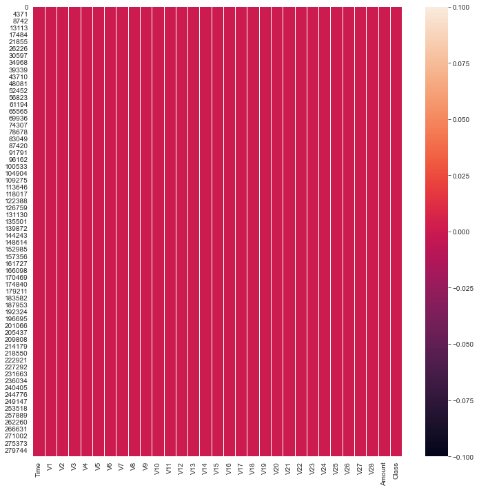

```python
#Visualization of nullvalues using heatmap
fig = plt.figure(figsize=(12,12))
sns.heatmap(data.isna())
```

[figure not shown]

```python
#Barplot showing the frequency of normal and fraud transactions.
LABELS = ["Normal" , "Fraud"]
count_classes = pd.value_counts(data['Class'],sort=True)
count_classes.plot(kind = 'barh')
plt.title("Transaction Class Distribution")
plt.xticks(range(2), LABELS)
plt.xlabel("Class")
plt.ylabel("frequency")
```

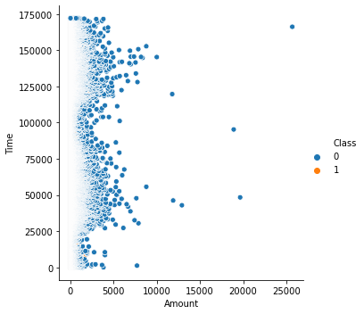

```python
#Relation plot for normal and fraud transactions
sns.relplot(x='Amount',y='Time',hue='Class',data=data)
```

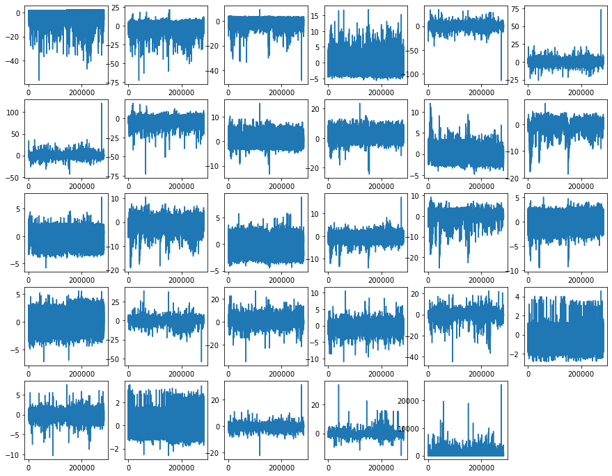

```python
fig = plt.figure(figsize = (15, 12))

plt.subplot(5, 6, 1) ; plt.plot(data.V1) ; plt.subplot(5, 6, 15) ; plt.plot(data.V15)
plt.subplot(5, 6, 2) ; plt.plot(data.V2) ; plt.subplot(5, 6, 16) ; plt.plot(data.V16)
plt.subplot(5, 6, 3) ; plt.plot(data.V3) ; plt.subplot(5, 6, 17) ; plt.plot(data.V17)
plt.subplot(5, 6, 4) ; plt.plot(data.V4) ; plt.subplot(5, 6, 18) ; plt.plot(data.V18)
plt.subplot(5, 6, 5) ; plt.plot(data.V5) ; plt.subplot(5, 6, 19) ; plt.plot(data.V19)
plt.subplot(5, 6, 6) ; plt.plot(data.V6) ; plt.subplot(5, 6, 20) ; plt.plot(data.V20)
plt.subplot(5, 6, 7) ; plt.plot(data.V7) ; plt.subplot(5, 6, 21) ; plt.plot(data.V21)
plt.subplot(5, 6, 8) ; plt.plot(data.V8) ; plt.subplot(5, 6, 22) ; plt.plot(data.V22)
plt.subplot(5, 6, 9) ; plt.plot(data.V9) ; plt.subplot(5, 6, 23) ; plt.plot(data.V23)
plt.subplot(5, 6, 10) ; plt.plot(data.V10) ; plt.subplot(5, 6, 24) ; plt.plot(data.V24)
plt.subplot(5, 6, 11) ; plt.plot(data.V11) ; plt.subplot(5, 6, 25) ; plt.plot(data.V25)
plt.subplot(5, 6, 12) ; plt.plot(data.V12) ; plt.subplot(5, 6, 26) ; plt.plot(data.V26)
plt.subplot(5, 6, 13) ; plt.plot(data.V13) ; plt.subplot(5, 6, 27) ; plt.plot(data.V27)
plt.subplot(5, 6, 14) ; plt.plot(data.V14) ; plt.subplot(5, 6, 28) ; plt.plot(data.V28)
plt.subplot(5, 6, 29) ; plt.plot(data.Amount)
plt.show()
```

### Feature density plot

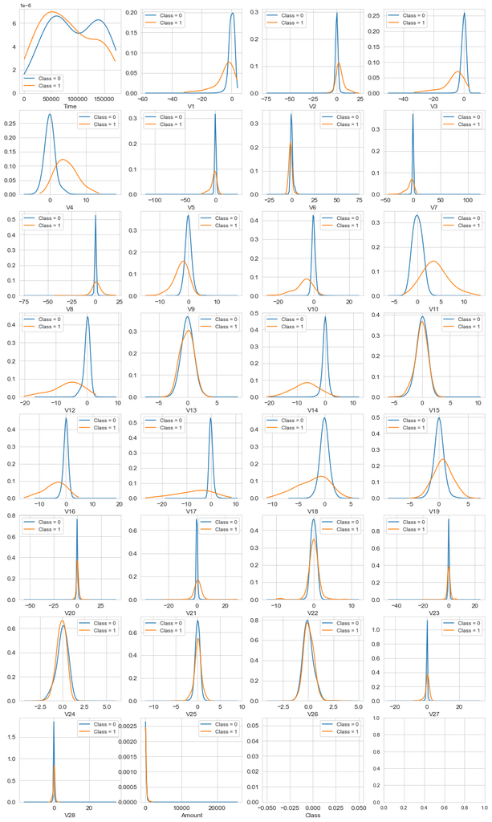

```python
import warnings
warnings.simplefilter('ignore')
var = data.columns.values

i = 0
normal = data.loc[data['Class'] == 0]
fraud = data.loc[data['Class'] == 1]

sns.set_style('whitegrid')
plt.figure()
fig, ax = plt.subplots(8,4,figsize=(16,28))

for feature in var:
    i += 1
    plt.subplot(8,4,i)
    sns.kdeplot(normal[feature], bw=0.5,label="Class = 0")
    sns.kdeplot(fraud[feature], bw=0.5,label="Class = 1")
    plt.xlabel(feature, fontsize=12)
    locs, labels = plt.xticks()
    plt.tick_params(axis='both', which='major', labelsize=12)
plt.show();
```

- For some of the features we can observe a good selectivity in terms of distribution for the two values of Class: V4, V11 have clearly separated distributions for Class values 0 and 1, V12, V14, V18 are partially separated, V1, V2, V3, V10 have a quite distinct profile, whilst V25, V26, V28 have similar profiles for the two values of Class.
- In general, with just few exceptions (Time and Amount), the features distribution for legitimate transactions (values of Class = 0) is centered around 0, sometime with a long queue at one of the extremities. In the same time, the fraudulent transactions (values of Class = 1) have a skewed (asymmetric) distribution.

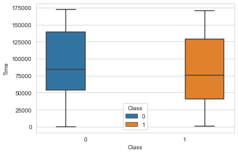

```python
#Boxplot showing the duration of transactions.
sns.boxplot(x = "Class", y = "Time",hue='Class', data = data)
plt.show()
```

By looking at the above box plot we can say that both fraud & genuine transactions occur throughout time and there is no distinction between them.

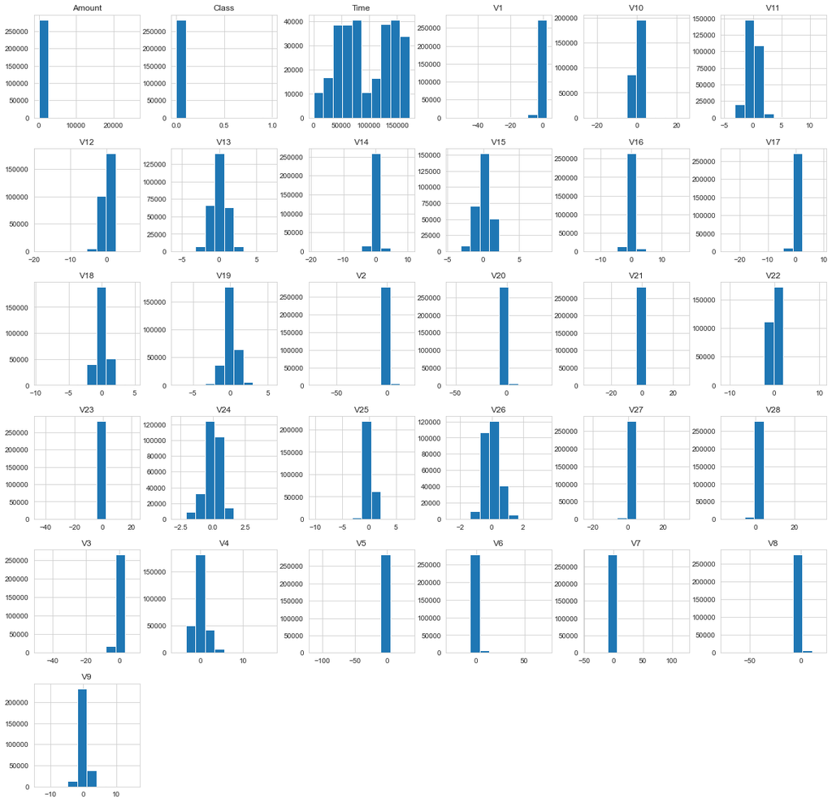

```python
data.hist(figsize=(20,20))
plt.show()
```

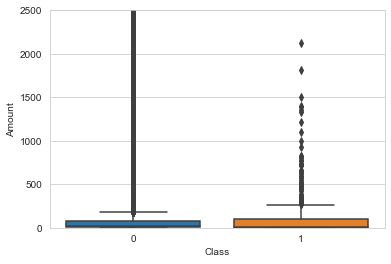

```python
sns.boxplot(x = "Class", y = "Amount", data = data)
plt.ylim(0, 2500)
plt.show()
```

From above box plot we can easily infer that there are no fraud transactions occur above the transaction amount of 2300. All of the fraud transactions have transaction amount less than 2300. However, there are many transactions which have a transaction amount greater than 2300 and all of them are genuine.

#### How different are the amount of money used in different transaction classes?

```python
fraud = data[data['Class']==1]
Normal = data[data['Class']==0]
print(fraud.shape,Normal.shape)
```

```
(492, 31) (283587, 31)
```

```python
fraud.Amount.describe()
```

```
count     492.000000
mean      122.211321
std       256.683288
min         0.000000
25%         1.000000
50%         9.250000
75%       105.890000
max      2125.870000
Name: Amount, dtype: float64
```

```python
Normal.Amount.describe()
```

```
count    283587.000000
mean         88.321519
std         249.608188
min           0.000000
25%           5.665000
50%          22.000000
75%          77.140000
max       25691.160000
Name: Amount, dtype: float64
```

#### Let's have a more graphical representation of the data

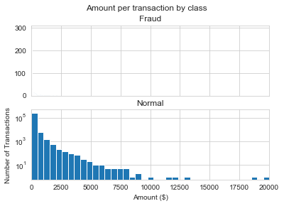

```python
# We Will check Do fraudulent transactions occur more often based on  certain amount ?
#Let us find out with a visual representation.
f, (ax1, ax2) = plt.subplots(2, 1,sharex = True)
f.suptitle('Amount per transaction by class')
bins = 50
ax1.hist(fraud.Amount, bins = bins)
ax1.set_title('Fraud')
ax2.hist(Normal.Amount, bins = bins)
ax2.set_title('Normal')
plt.xlabel('Amount ($)')
plt.ylabel('Number of Transactions')
plt.xlim((0, 20000))
plt.yscale('log')
plt.show();
```

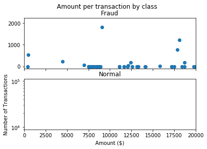

```python
f, (ax1, ax2) = plt.subplots(2, 1,sharex=True)
f.suptitle('Amount per transaction by class')
ax1.scatter(fraud.Time, fraud.Amount)
ax1.set_title('Fraud')
ax2.scatter(Normal.Time, Normal.Amount)
ax2.set_title('Normal')
plt.xlabel('Amount ($)')
plt.ylabel('Number of Transactions')
plt.xlim((0, 20000))
plt.yscale('log')
plt.show();
```

#### We Will check Do fraudulent transactions occur more often during certain time frame ?

#### Let us find out with a visual representation.

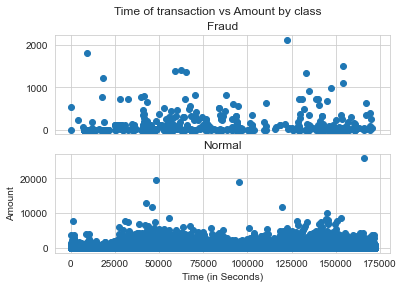

```python
f, (ax1, ax2) = plt.subplots(2, 1,sharex=True)
f.suptitle('Time of transaction vs Amount by class')
ax1.scatter(fraud.Time, fraud.Amount)
ax1.set_title('Fraud')
ax2.scatter(Normal.Time, Normal.Amount)
ax2.set_title('Normal')
plt.xlabel('Time (in Seconds)')
plt.ylabel('Amount')
plt.show()
```

```python
Fraud = data[data['Class']==1]
Valid = data[data['Class']==0]
outlier_fraction = len(Fraud)/float(len(Valid))
```

```python
print(outlier_fraction)
print("Fraud Cases : {}".format(len(Fraud)))
print("Valid Cases : {}".format(len(Valid)))
```

```
0.0017349173269578647
Fraud Cases : 492
Valid Cases : 283587
```

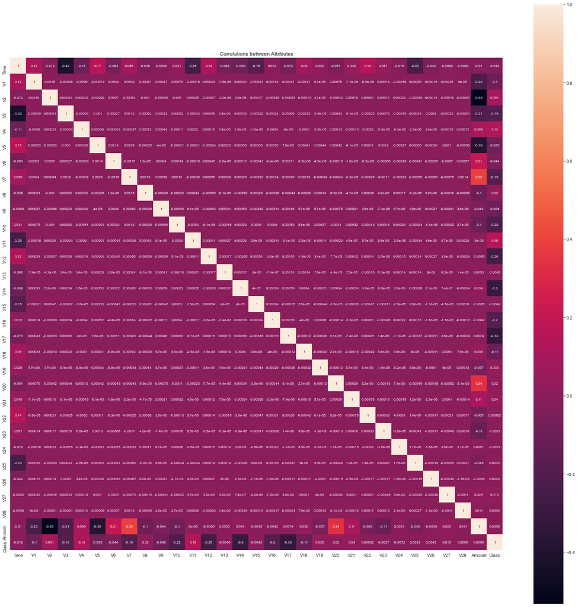

```python
fig = plt.subplots (figsize = (25, 25))
sns.heatmap(data.corr (), square = True, cbar = True, annot = True, annot_kws = {'size': 8})
plt.title('Correlations between Attributes')
plt.show ()
```

The above correlation matrix shows that none of the V1 to V28 PCA components have any correlation to each other however if we observe Class has some form positive and negative correlations with the V components but has no correlation with Time and Amount.

### Balancing the dataset

```python
#To calculate number of fraud and normal transactions
fraud = data[data['Class']==1]
Normal = data[data['Class']==0]
print(fraud.shape,Normal.shape)
```

```
(492, 31) (283587, 31)
```

```python
from imblearn.combine import SMOTETomek
smk = SMOTETomek(random_state=120)
X,y = smk.fit_sample(data.drop(['Class'],axis=1),data['Class'])
```

```python
y.value_counts()
```

```
1    283045
0    283045
Name: Class, dtype: int64
```

```python
#Splitting the dataset into training and test data.
from sklearn.model_selection import train_test_split
X_train,X_test,y_train,y_test = train_test_split(X,y,test_size=0.2,random_state=1)
```

```python
print(X_train.shape)
print(X_test.shape)
print(y_train.shape)
print(y_test.shape)
```

```
(452872, 30)
(113218, 30)
(452872,)
(113218,)
```

### Logistic regression

```python
from sklearn.linear_model import LogisticRegression
log_reg = LogisticRegression() # creating an object for Logistic Regression
# we have to apply this object(Log_reg) to the training data
final_model1 = log_reg.fit(X_train,y_train) # with the help of fit method we are fitting logistic regression with training data
##objectName.fit(InputData, outputData)
```

#### Instead of directly predicting on test data, let us see how well the model predicts the training data

- Predicting on the training data

`syntax: objectName.predict(Input)`

```python
y_train_pred = log_reg.predict(X_train) #Predicting on train data
y_train_pred
```

```
array([0, 0, 0, ..., 1, 1, 0], dtype=int64)
```

```python
y_train == y_train_pred # comparing original data o/p and model predicted o/p
```

```
40281     True
200590    True
49273     True
322477    True
332369    True
          ...
371403    True
491263    True
470924    True
491755    True
128037    True
Name: Class, Length: 452872, dtype: bool
```

```python
#applying metrics on training data
from sklearn.metrics import classification_report,confusion_matrix
confusion_matrix(y_train,y_train_pred)
```

```
array([[221942,   4458],
       [  8109, 218363]], dtype=int64)
```

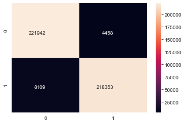

```python
from sklearn.metrics import confusion_matrix;
sns.heatmap(confusion_matrix(y_train, y_train_pred), annot=True, fmt='d', annot_kws={'va':'top', 'ha':'right'})
```

```python
#Accuracy score for training data
from sklearn.metrics import accuracy_score
accuracy_score(y_train,y_train_pred)
```

```
0.972250437209631
```

```python
#f1-score for training data
from sklearn.metrics import f1_score
f1_score(y_train, y_train_pred)
```

```
0.9720293883946557
```

```python
# Predicting the model on test data
y_test_pred = log_reg.predict(X_test)
```

```python
y_test_pred
```

```
array([1, 1, 0, ..., 1, 0, 1], dtype=int64)
```

```python
y_test == y_test_pred  # comparing original data o/p and model predicted o/p
```

```
327747    True
421980    True
216522    True
561063    True
271054    True
          ...
24611     True
451136    True
322330    True
157770    True
377635    True
Name: Class, Length: 113218, dtype: bool
```

```python
#applying metrics on test data
confusion_matrix(y_test,y_test_pred)
```

```
array([[55497,  1148],
       [ 2047, 54526]], dtype=int64)
```

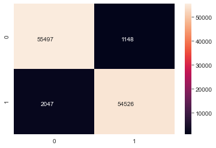

```python
from sklearn.metrics import confusion_matrix;
sns.heatmap(confusion_matrix(y_test, y_test_pred), annot=True, fmt='d', annot_kws={'va':'top', 'ha':'right'})
```

```python
#Accuracy score for test data
accuracy_score(y_test,y_test_pred)
```

```
0.9717801056369129
```

```python
#f1-score for test data
from sklearn.metrics import f1_score
f1_score(y_test, y_test_pred)
```

```
0.9715359875987777
```

```python
#classification report on training and test data
from sklearn.metrics import classification_report,confusion_matrix
print(classification_report(y_train,y_train_pred))
print("-----------------------------------------------------")
print(classification_report(y_test,y_test_pred))
```

```
              precision    recall  f1-score   support

           0       0.96      0.98      0.97    226400
           1       0.98      0.96      0.97    226472

    accuracy                           0.97    452872
   macro avg       0.97      0.97      0.97    452872
weighted avg       0.97      0.97      0.97    452872

-----------------------------------------------------
              precision    recall  f1-score   support

           0       0.96      0.98      0.97     56645
           1       0.98      0.96      0.97     56573

    accuracy                           0.97    113218
   macro avg       0.97      0.97      0.97    113218
weighted avg       0.97      0.97      0.97    113218
```

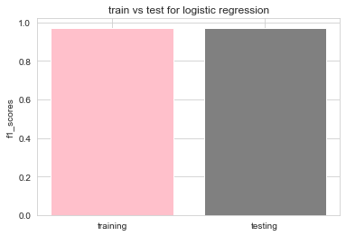

```python
models = ['training','testing']
f1_scores = [0.9720293883946557,0.9715359875987777]
plt.bar(models, f1_scores, color=['pink', 'grey' ])
plt.ylabel("f1_scores")
plt.title("train vs test for logistic regression")
plt.show()
```

#### Observations:

- Training data f1-score in logistic regression: 97.2%
- Testing data f1-score in logistic regression:97.1%

### Plot the ROC Curve for the model and find the AUC for LogisticRegression

```python
#import the roc_auc_score, roc_curve from sklearn.metrics
from sklearn.metrics import roc_auc_score, roc_curve
fraud_prob1 = final_model1.predict_proba(X_test)[:,1]
fpr1, tpr1, threshold1 = roc_curve(y_test, fraud_prob1)
```

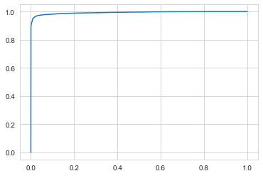

```python
plt.plot(fpr1, tpr1) #roc_curve for logistic regression
```

```python
roc_auc_score(y_test, fraud_prob1)
```

```
0.9930221417934557
```

### Random forest classification

```python
#import initialize and fit
#import the RFC from sklearn
from sklearn.ensemble import RandomForestClassifier

#initialize the object for RFC
rfc = RandomForestClassifier()

#fit RFC to dataset
final_model2 = rfc.fit(X_train,y_train)
```

```python
y_train_pred1 = rfc.predict(X_train) #Predicting on training data
```

```python
#Applying metrics on training data
confusion_matrix(y_train,y_train_pred1)
```

```
array([[226400,      0],
       [     0, 226472]], dtype=int64)
```

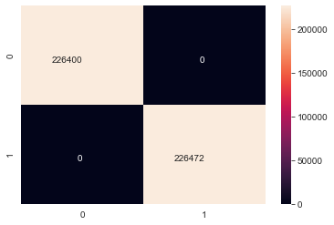

```python
from sklearn.metrics import confusion_matrix;
sns.heatmap(confusion_matrix(y_train, y_train_pred1), annot=True, fmt='d', annot_kws={'va':'top', 'ha':'right'})
```

```python
#accuracy score for training data
accuracy_score(y_train,y_train_pred1)
```

```
1.0
```

```python
#f1-score for training data
from sklearn.metrics import f1_score
f1_score(y_train, y_train_pred1)
```

```
1.0
```

```python
y_test_pred1 = rfc.predict(X_test) #Predicting on test data
```

```python
#Applying metrics on test data
confusion_matrix(y_test,y_test_pred1)
```

```
array([[56636,     9],
       [    0, 56573]], dtype=int64)
```

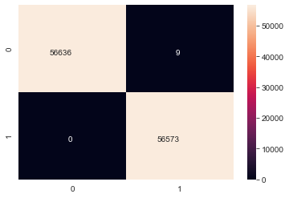

```python
from sklearn.metrics import confusion_matrix;
sns.heatmap(confusion_matrix(y_test, y_test_pred1), annot=True, fmt='d', annot_kws={'va':'top', 'ha':'right'})
```

```python
#accuracy score for test data
accuracy_score(y_test,y_test_pred1)
```

```
0.9999205073398223
```

```python
#f1-score for test data
from sklearn.metrics import f1_score
f1_score(y_test, y_test_pred1)
```

```
0.9999204630816138
```

```python
#Applying metrics on training and test data and generating classification report.
from sklearn.metrics import classification_report,confusion_matrix
print(classification_report(y_train,y_train_pred1))
print("------------------------------------------------------")
print(classification_report(y_test,y_test_pred1))
```

```
              precision    recall  f1-score   support

           0       1.00      1.00      1.00    226400
           1       1.00      1.00      1.00    226472

    accuracy                           1.00    452872
   macro avg       1.00      1.00      1.00    452872
weighted avg       1.00      1.00      1.00    452872

------------------------------------------------------
              precision    recall  f1-score   support

           0       1.00      1.00      1.00     56645
           1       1.00      1.00      1.00     56573

    accuracy                           1.00    113218
   macro avg       1.00      1.00      1.00    113218
weighted avg       1.00      1.00      1.00    113218
```

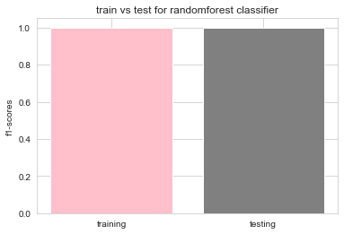

```python
models = ['training','testing']
f1_scores = [1.0,0.9999204630816138]
plt.bar(models, f1_scores, color=['pink', 'grey' ])
plt.ylabel("f1-scores")
plt.title("train vs test for randomforest classifier")
plt.show()
```

#### Observations:

- Training data f1-score in Random forest classifier: 100%
- Testing data f1-score in Random forest classifier:99%

### Plot the ROC Curve for the model and find the AUC for Randomforest

```python
#import the roc_auc_score, roc_curve from sklearn.metrics
from sklearn.metrics import roc_auc_score, roc_curve
fraud_prob2 = final_model2.predict_proba(X_test)[:,1]
fpr2, tpr2, threshold2 = roc_curve(y_test, fraud_prob2)
```

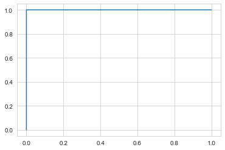

```python
plt.plot(fpr2, tpr2)    #roc_curve for Random forest
```

```python
roc_auc_score(y_test, fraud_prob2)
```

```
0.9999807456682314
```

### Naive bayes

```python
#import initialize and fit
#import the GaussianNB from sklearn.naive_bayes
from sklearn.naive_bayes import GaussianNB

#initialize the object for GaussianNB
gn = GaussianNB()

#fit GaussianNB to dataset
final_model3 = gn.fit(X_train,y_train)

#Predicting on training data
y_train_pred2 = gn.predict(X_train)
```

```python
#Applying metrics on training data
confusion_matrix(y_train,y_train_pred2)
```

```
array([[224757,   1643],
       [ 57978, 168494]], dtype=int64)
```

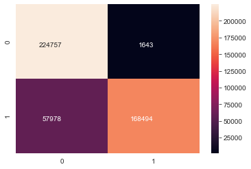

```python
from sklearn.metrics import confusion_matrix;
sns.heatmap(confusion_matrix(y_train, y_train_pred2), annot=True, fmt='d', annot_kws={'va':'top', 'ha':'right'})
```

```python
#accuracy score for training data
from sklearn.metrics import accuracy_score
accuracy_score(y_train,y_train_pred2)
```

```
0.8683491140984649
```

```python
#f1-score for training data
from sklearn.metrics import f1_score
f1_score(y_train, y_train_pred2)
```

```
0.8496731037369297
```

```python
y_test_pred2 = gn.predict(X_test) #Predicting on test data
```

```python
#Applying metrics on test data
confusion_matrix(y_test,y_test_pred2)
```

```
array([[56254,   391],
       [14609, 41964]], dtype=int64)
```

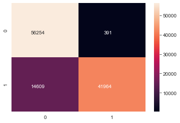

```python
from sklearn.metrics import confusion_matrix;
sns.heatmap(confusion_matrix(y_test, y_test_pred2), annot=True, fmt='d', annot_kws={'va':'top', 'ha':'right'})
```

```python
#accuracy score for test data
accuracy_score(y_test,y_test_pred2)
```

```
0.8675122330371495
```

```python
#f1-score for test data
from sklearn.metrics import f1_score
f1_score(y_test, y_test_pred2)
```

```
0.8483745754488113
```

```python
#Applying metrics on training and test data and generating classification report.
from sklearn.metrics import classification_report,confusion_matrix
print(classification_report(y_train,y_train_pred2))
print("------------------------------------------------------")
print(classification_report(y_test,y_test_pred2))
```

```
              precision    recall  f1-score   support

           0       0.79      0.99      0.88    226400
           1       0.99      0.74      0.85    226472

    accuracy                           0.87    452872
   macro avg       0.89      0.87      0.87    452872
weighted avg       0.89      0.87      0.87    452872

------------------------------------------------------
              precision    recall  f1-score   support

           0       0.79      0.99      0.88     56645
           1       0.99      0.74      0.85     56573

    accuracy                           0.87    113218
   macro avg       0.89      0.87      0.87    113218
weighted avg       0.89      0.87      0.87    113218
```

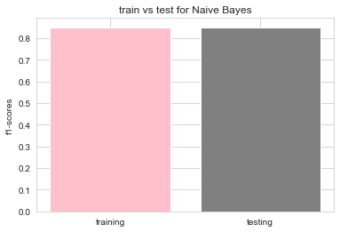

```python
models = ['training','testing']
f1_scores = [0.8496731037369297,0.8483745754488113]
plt.bar(models, f1_scores, color=['pink', 'grey' ])
plt.ylabel("f1-scores")
plt.title("train vs test for Naive Bayes")
plt.show()
```

#### Observations:

- Training data f1-score in Naive Bayes: 84.9%
- Testing data f1-score in Naive Bayes:84.8%

### Plot the ROC Curve for the model and find the AUC for NaiveBayes

```python
#1-->fraud 0-->genuine
# Roc curve
## TPR, FPR, Threshold
from sklearn.metrics import roc_auc_score, roc_curve
fraud_prob3 = final_model3.predict_proba(X_test)[:,1]
fpr3, tpr3, threshold3 = roc_curve(y_test, fraud_prob3)
```

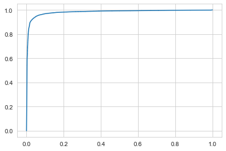

```python
plt.plot(fpr3, tpr3)  #roc_curve for Random forest
```

```python
roc_auc_score(y_test, fraud_prob3)
```

```
0.9825882357284228
```